# Data Translation Project

Valentina Bernal

2022-05-19

```r
# Some EDA

summary(ov)
```

```
##    naics_code     naics_title           brands             GEOID
##  Min.   :  3231   Length:210682      Length:210682      Length:210682
##  1st Qu.:447110   Class :character   Class :character   Class :character
##  Median :523930   Mode  :character   Mode  :character   Mode  :character
##  Mean   :565494
##  3rd Qu.:722410
##  Max.   :928120
##
##      visits
##  Min.   :   4.00
##  1st Qu.:   4.00
##  Median :   4.00
##  Mean   :   8.45
##  3rd Qu.:   8.00
##  Max.   :1072.00
##  NA's   :179
```

```r
summary(dv)
```

```
##       date              naics_code     naics_title           brands
##  Min.   :2020-07-01   Min.   :  3231   Length:37014       Length:37014
##  1st Qu.:2020-07-08   1st Qu.:446120   Class :character   Class :character
##  Median :2020-07-16   Median :517312   Mode  :character   Mode  :character
##  Mean   :2020-07-16   Mean   :553629
##  3rd Qu.:2020-07-24   3rd Qu.:721110
##  Max.   :2020-07-31   Max.   :928120
##  visits_by_day
##  Min.   :    0.0
##  1st Qu.:    2.0
##  Median :    9.0
##  Mean   :  102.5
##  3rd Qu.:   43.0
##  Max.   :15129.0
```

```r
vtable::vtable(ov)
```

ov

| Name | Class | Values |
| --- | --- | --- |
| naics_code | integer | Num: 3231 to 928120 |
| naics_title | character |  |
| brands | character |  |
| GEOID | character |  |
| visits | numeric | Num: 4 to 1072 |

```r
vtable::vtable(dv)
```

dv

| Name | Class | Values |
| --- | --- | --- |
| date | Date | Time: 2020-07-01 to 2020-07-31 |
| naics_code | integer | Num: 3231 to 928120 |
| naics_title | character |  |
| brands | character |  |
| visits_by_day | integer | Num: 0 to 15129 |

```r
# What brands are available
dv %>%
  group_by(brands) %>%
  select(naics_title, brands, visits_by_day)
```

```
## # A tibble: 37,014 × 3
## # Groups:   brands [958]
##    naics_title brands visits_by_day
##    <chr>       <chr>          <int>
##  1 <NA>        ""               424
##  2 <NA>        ""               392
##  3 <NA>        ""               368
##  4 <NA>        ""               252
##  5 <NA>        ""               248
##  6 <NA>        ""               392
##  7 <NA>        ""               381
##  8 <NA>        ""               348
##  9 <NA>        ""               406
## 10 <NA>        ""               451
## # … with 37,004 more rows
```

```r
# Where are there highest varieties of GEOID influxes?
brand_names <- ov %>%
  select(brands) %>%
  count(brands) %>%
  arrange(desc(n))

# Removing row including all empty brands (local brands)
brand_names <- brand_names[!brand_names$brands=="",]

# What are the most commonly recorded visits for industries and their associated codes?
popular_visit <- dv %>%
  group_by(naics_code) %>%
  mutate(tot_visits = sum(visits_by_day)) %>%
  select(naics_code, naics_title, tot_visits) %>%
  unique() %>%
  arrange(desc(tot_visits))

# Viewing the industries with code beginning with 712
popularID <- popular_visit %>%
  group_by(naics_code) %>%
  mutate(filter_code = floor(naics_code/1000)) %>%
  filter(filter_code == 712)

# Exploring 311 code which identifies food/consumption product manufacturers

exploreID <- dv

# Removing the rows with empty brand inputs
exploreID <- exploreID[!exploreID$brands=="",]

# Focusing on codes beginning with 311 (broad category of food industries/manufacturers)
ID <- exploreID %>%
  group_by(brands) %>%
  mutate(three_digit_id = floor(naics_code/1000)) %>%
  filter(three_digit_id == 311)

# Exploring medical centers
hospitals <- dv %>%
  group_by(brands) %>%
  #mutate(three_digit_id = floor(naics_code/1000)) %>%
  filter(naics_code == 622110)
```

As I explore the data, I found different aspects of each data set that are intriguing to dig into. For instance, different brand names from the origin visits data have higher/lower influxes of people coming from different areas of Seattle based on their GEOID’s. I can infer that these businesses are popular based on the higher or lower varieties of GEOID and their reaches. From the daily visits data I found that the two highest recorded visits from cellphone tracking data were found within the naics_code were from Lessor data (where people live) and recreational city attractions (like nature parks).

### Story: Contrary to popular opinion and despite the rainy weather, Seattle residents spend a large amount of time outdoors and visit recreational parks/institutions more than other perceived popular destinations.

### In what naics_codes are there high recordings of people visiting?

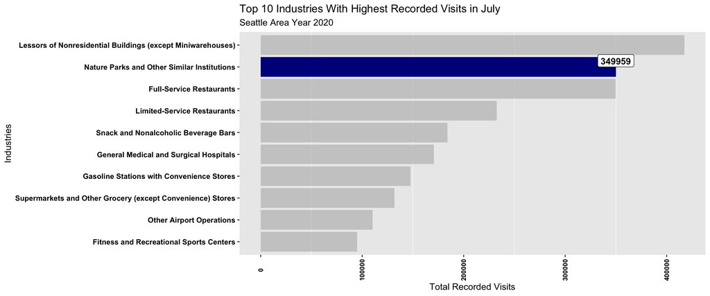

```r
# Remove scientific notation
options(scipen = 999)

# Overall view of top 10 highest visit recordings in the month of July
top10_visit <- popular_visit %>%
  head(10)
view(top10_visit)

# Creating horizontal bar graph
top10_visit %>%
  ggplot(aes(x = reorder(naics_title, tot_visits), tot_visits, y = tot_visits)) + geom_col(fill = 'dark blue') + theme(axis.text.x = element_text(angle = 90, vjust = 0.5)) +
  coord_flip() +
  theme(axis.text.x = element_text(face="bold", color="black", size=8), axis.text.y = element_text(face="bold", color="black", size=9), panel.grid.major = element_blank()) +
  labs(x = 'Industries', y = 'Total Recorded Visits', title = 'Top 10 Industries With Highest Recorded Visits in July', subtitle = 'Seattle Area Year 2020') +
  gghighlight(naics_title == 'Nature Parks and Other Similar Institutions' ) + geom_label(aes(label = tot_visits, label.padding = unit(0.55, "lines"), label.size = 0.35, vjust = 0, fontface = 'bold'))
```

From the top 10 industries with the highest recorded visits in Seattle during July, the second-highest position of the colored column of ‘Nature Parks and Other Similar Institutions’ is notable in comparison to ‘Snack & Non-Alcoholic Beverage Bars’ as Seattle is often known for the diverse food and coffee culture.

### Comparing Nature Parks and Other Institutions to Snack/Non-Alcoholic Beverage Bars

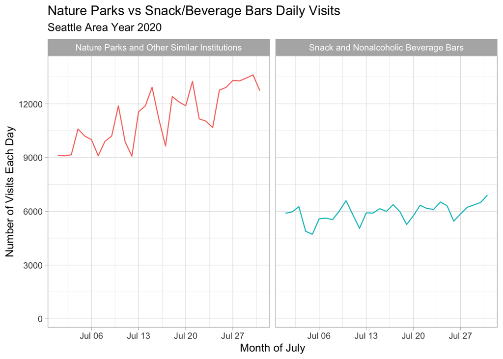

```r
# Looking at daily visits for both types of industries
short_code <- dv %>%
  group_by(naics_title, date) %>%
  mutate(dailyvisits = sum(visits_by_day)) %>%
  filter(naics_code %in% c(722515, 712190))

# Plotting total daily visits of all brands in industries for the days of July
short_code %>%
  ggplot(aes(x = date, y = dailyvisits, color = naics_title)) + geom_line() +
  facet_wrap('naics_title') +
  theme(axis.text.x=element_blank(),
      axis.ticks.x=element_blank(),
      axis.text.y = element_text(size = 10,family='serif', colour = 'black')) +
  scale_y_continuous(breaks = c(0, 3000, 6000, 9000, 12000), limits = c(200,14000)) + labs(x = 'Month of July', y = 'Number of Visits Each Day', title = 'Nature Parks vs Snack/Beverage Bars Daily Visits', subtitle= 'Seattle Area Year 2020') +  guides(color = 'none') + theme_light()
```

Throughout the month of July, for each day there are significantly more visits recorded for Nature Parks & Other Institutions compared to that of Snack and Beverage Bars which are often considered popular destinations across Seattle.

### How popular are the other industries within the same three digit code (712)?

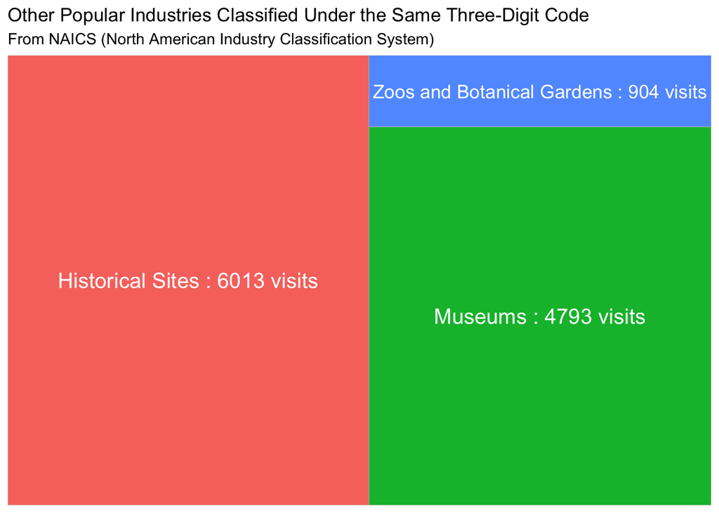

```r
view(popularID)

# Not accounting for Nature Parks & Other Institutions Category
classID <- popularID %>%
  filter(naics_code %in% c(712120, 712110, 712130))

# Creating treemap
classID %>%
  ggplot(aes(area = tot_visits, fill = naics_title, label = paste0(naics_title, sep = " : ", tot_visits, " visits" ))) +
  geom_treemap() +
  geom_treemap_text(colour = "white",
                    place = "centre",
                    size = 15) +
  theme(legend.position = "none") +
  labs(title = 'Other Popular Industries Classified Under the Same Three-Digit Code', subtitle = 'From NAICS (North American Industry Classification System)')
```

The above industries total visits of July amount to less than the broadest category of Nature Parks and Other Similar Institutions, but are still popular destinations in comparison to other categories.

### Where are people coming from to visit these destinations?

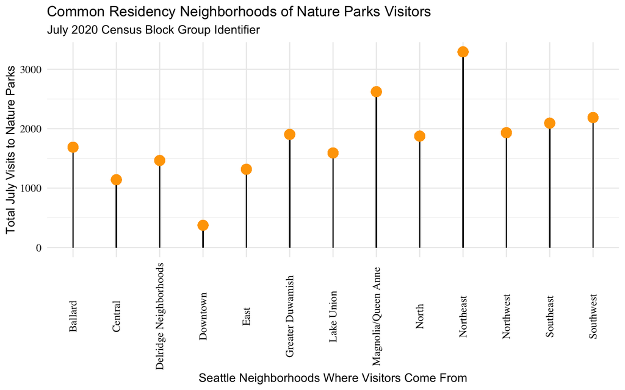

```r
# Joining origin visits data to see what the neighborhoods the census blocks include
join_origin <- ov %>%
  right_join(neighborhood_names)

# Visits to Nature Parks/Other institutions from each neighborhood
natureID <- join_origin %>%
  filter(naics_code == 712190) %>%
  group_by(NEIGHBORHOOD_DISTRICT_NAME) %>%
  mutate(neighborhood_visits = (sum(visits)))

natureID %>%
  ggplot(aes(x = NEIGHBORHOOD_DISTRICT_NAME , y = neighborhood_visits)) +
  geom_lollipop(point.colour = 'orange', point.size = 4) + theme_minimal() +
  labs(x = 'Seattle Neighborhoods Where Visitors Come From', y = 'Total July Visits to Nature Parks', title = 'Common Residency Neighborhoods of Nature Parks Visitors', subtitle = 'July 2020 Census Block Group Identifier') +
  theme(axis.text.x = element_text(size = 10,family='serif', colour = 'black', angle = 90, vjust = 0.5),
        axis.text.y = element_text(size = 10,family='serif', colour = 'black'))
```

The influx of people’s and the neighborhoods they are visiting Nature Parks & Other Similar Institutions from is evidently varied and has the highest amount coming from Northeast neighborhoods.

### Nature Parks Popularity Over the Month of July

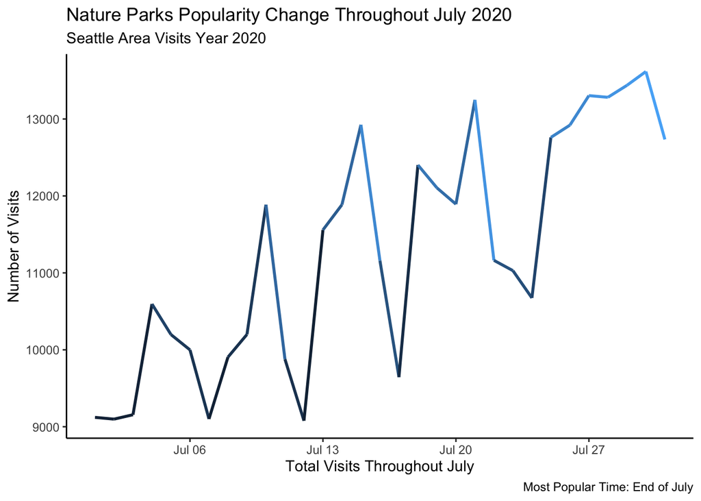

```r
month_growth <- dv %>%
  group_by(naics_title, date) %>%
  mutate(dailyvisits = sum(visits_by_day)) %>%
  filter(naics_code == 712190)

month_growth %>%
ggplot(aes(x = date, y = dailyvisits, color = dailyvisits)) +
  geom_line(size = 1) +
  labs(x = 'Total Visits Throughout July', y = 'Number of Visits', color = 'Variables',
       title = 'Nature Parks Popularity Change Throughout July 2020', subtitle = 'Seattle Area Visits Year 2020', caption = 'Most Popular Time: End of July') + guides(color = 'none') + theme_classic()
```

There is fluctuation among the visits of each day of July 2020 but that is largely because the time accounted for is shorter than if this data was looked at throughout a longer period of time. With that being said, the increase in visits throughout the month is evidently increasing slowly but surely.